# Egzaminas

```r
accuracy(mod4_4)
```

```
##                         ME       RMSE        MAE       MPE    MAPE
## Training set -0.0004861918 0.02967858 0.02175472 -12.01578 64.2569
##                   MASE      ACF1
## Training set 0.1942642 -0.168814
```

```r
#pagal rmse geriausias yra mod3_3, nes rmse maziausias
```

4. Išbrėžkite visų keturių modelių prognozes (su pasikliautinais intervalais). Ir ant viršau išbrėžkite faktines reikšmes iš `testSet` duomenų. Kuri prognozė atrodo geriausia?

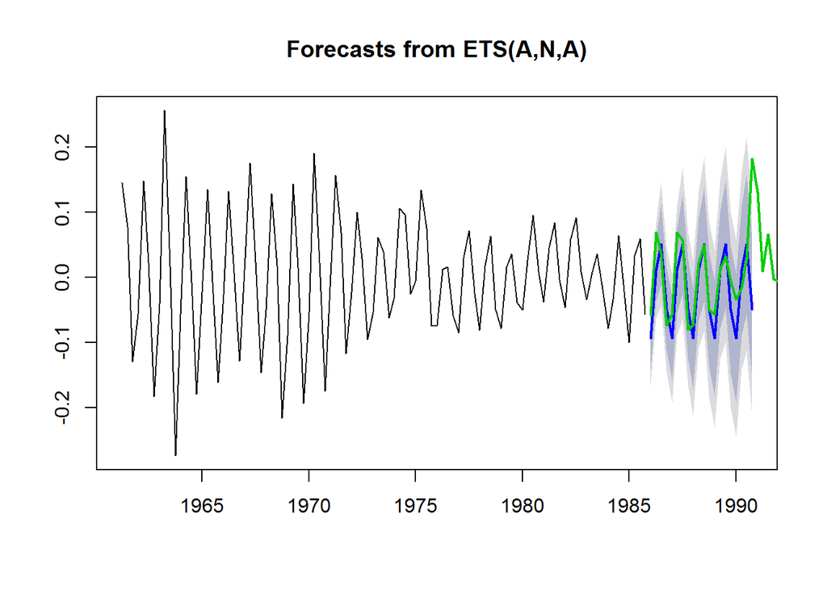

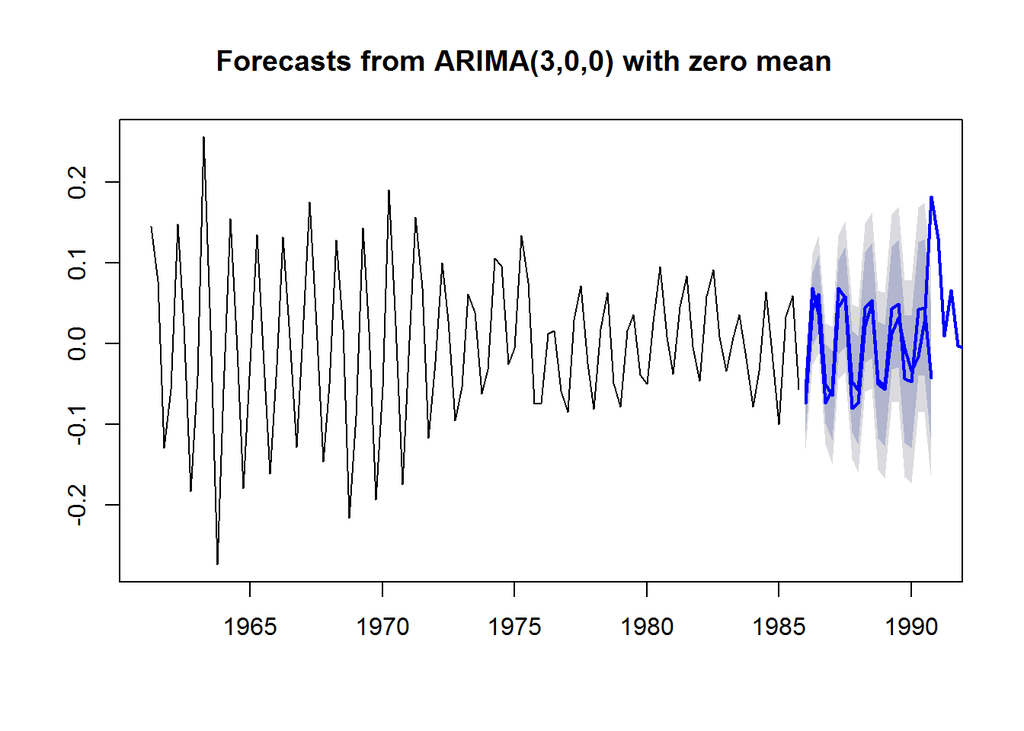

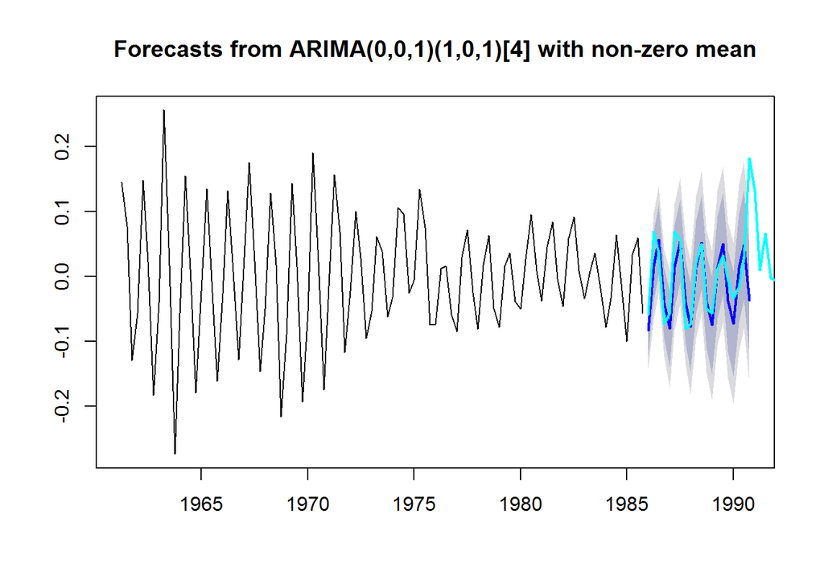

5. Patikrinkite visų modelių tikslumą su funkciją `accuracy`. Turi matytis tikslumas `trainSet` ir `testSet` duomenims. Kuris modelis atrodo geriausias? Pasirinktą modelį vadinsime `modMain`.

```r
#Fiksuojame prognozes
f_mod1_1<-forecast(mod1_1, h=20)
f_mod3_3<-forecast(mod3_3, h=20)
f_mod4_4<-forecast(mod4_4, h=20)

tab1 = rbind(
  accuracy(f_mod1_1, ser)[,2],
  accuracy(f_mod3_3, ser)[,2],
  accuracy(f_mod4_4, ser)[,2]
)
rownames(tab1) <- c("f_mod1_1", "f_mod3_3", "f_mod4_4")
kable(tab1, digits=3)
```

|  | Training set | Test set |
| --- | --- | --- |
| f_mod1_1 | 0.037 | 0.082 |
| f_mod3_3 | 0.028 | 0.089 |
| f_mod4_4 | 0.030 | 0.083 |

```r
#training set maziausias rmse yra f_mod3_3, o test set maziausias rmse yra f_mod1_1.taciau as pasirenku modeli f_mod3_3, nes jo ir grafikas atrodo tiksliausiai
modMain<-f_mod3_3
```

4. Tikslumo tyrimas. Parašykite R procedūrą, kurios psiaudo-kodas atorodo taip:

```
tikslumas(i):
    subset = eilutės ser dalis nuo pirmo stebėjimo iki i-tojo.
    modeliui modMain pritaikyti subset duomenis (modelio nepervertinti)
    tuomet gauti prognozes i+1, ..., i+20 laikotarpiams
    suskaiciuoti gautu prognoziu RMSE
    funkcija grazina RMSE
```

```r
#tikslumas<-function(i){
#    subset = window(ser, start=1, end=i)
#nezinau kaip toliau rasyti funkcija
```

Šią funkciją pritaikykite skirtingiems i ir išbrėžkite grafiką, kuriame matytųsi RMSE priklausomybę nuo i. Kaip interpretuoti šį grafiką?